# trees_graphs_combined

Don Radcliffe

4/27/2021

# Introduction

This script is for graphing the stand structure variables basal area, density, and qmd, in order to get a better sense of the study site for brainstorming analyses. It includes both Lake Roosevelt and Stehekin data, the first draft that included just Stehekin data is still saved as a separate file.

# Setup and formatting code

```r
require(here)
require(dplyr)
require(ggplot2)

import_dir_tg <- here::here('data', 'data_tidy')
export_dir_tg <- here::here('plots', 'trees')

trees_raw <- read.csv(file.path(import_dir_tg, 'trees_tidy.csv'))
plot_data_raw <- read.csv(file.path(import_dir_tg, 'plot_visit_data.csv'))
```

```r
trees <- full_join(trees_raw, plot_data_raw, by = 'plot_visit') %>%
  ## -2 means early pretreatment read, only want to use most recent pretreatment read
  filter(years_post != -2) %>%
  ## There are some weird zeros in the data that
  filter(status == 'l') %>%
  ## Arrange treatments in some kind of order.
  mutate(treatment = factor(treatment, levels = c('pretreatment_current', 'pileburn', 'pileburn_pileburn',
                               'burn', 'thin',
                               'thin_burn', 'thin_burn_burn',
                               'thin_thin_burn', 'thin_thin_burn_burn','thin_thin_burn_burn_burn',
                               'thin_pileburn', 'thin_thin_pileburn_pileburn'))) %>%
  ## Arrange areas by proximity to Stehekin for North Cascades,
  ## then for Lake Roosevelt by proximity to the Grand Coulee Dam
  ## don't see Bullion on my map, maybe it replaced a problematic older name that's farthest away.
  mutate(area = factor(area, levels = c(## North Cascades
                                        'weaver', 'boulder', 'orchard rainbow', 'company creek',
                                        'lower mcgregor', 'mcgregor', 'upper mcgregor', 'bullion',
                                        ## Lake Roosevelt
                                        'sterling valley', 'ft. spokane', 'ponderosa', 'riverway b',
                                        'enterprise', 'clark', 'gifford ferry', 'gifford clover',
                                        'copa', 'bradbury beach', 'ricky point',
                                        'ricky north', 'kettle falls', 'log yard c', 'evans', 'north gorge'))) %>%
  mutate(region = factor(region, levels = c('north cascades', 'lake roosevelt')))

str(trees)
```

```
## 'data.frame':    523 obs. of  17 variables:
##  $ plot_visit       : chr  "lr01_2001_-1_-1" "lr01_2002_02_01" "lr01_2006_04_02" "lr01_2009_04_05" ...
##  $ status           : chr  "l" "l" "l" "l" ...
##  $ basal_area       : num  18.4 8.6 0.7 0.6 21.4 21.9 22 0.8 22.6 0.9 ...
##  $ density          : int  1320 140 10 10 140 140 140 10 140 30 ...
##  $ qmd              : num  13.3 27.9 29 28.6 44.1 44.6 44.8 32.4 45.3 19.8 ...
##  $ plot             : chr  "lr01" "lr01" "lr01" "lr01" ...
##  $ region           : Factor w/ 2 levels "north cascades",..: 2 2 2 2 2 2 2 2 2 2 ...
##  $ area             : Factor w/ 24 levels "weaver","boulder",..: 23 23 23 23 9 9 9 23 9 23 ...
##  $ year             : int  2001 2002 2006 2009 2011 2013 2014 2014 2017 2019 ...
##  $ date             : chr  "2001/07/22" "2002/06/08" "2006/07/30" "2009/05/14" ...
##  $ treatment_code   : int  -1 2 4 4 -1 3 3 4 3 5 ...
##  $ years_post       : int  -1 1 2 5 -1 1 2 10 5 0 ...
##  $ treatment        : Factor w/ 12 levels "pretreatment_current",..: 1 5 6 6 1 2 2 6 2 7 ...
##  $ burns            : int  0 0 1 1 0 0 0 1 0 2 ...
##  $ thins            : int  0 1 1 1 0 0 0 1 0 1 ...
##  $ pileburns        : int  0 0 0 0 0 1 1 0 1 0 ...
##  $ monitoring_status: chr  "-1pre-1" "02year01" "04year02" "04year05" ...
```

# Graphing code

```r
## Theme for graphing.
simpletheme <- theme(panel.grid.major = element_blank(),
                     panel.grid.minor = element_blank(),
                     panel.background = element_blank()) +
  theme(plot.title = element_text(hjust = 0.5)) +
  theme(axis.ticks = element_blank()) +
  theme(axis.line = element_line(size = 0.2, color = 'black')) +
  theme(legend.key=element_blank(), legend.background=element_blank())

## Common color scheme for areas
#area_colors <- c('weaver' = 'gray0', 'boulder' = 'gray8', 'orchard rainbow' = 'gray16', 'company creek' = 'gray24', 'lower mcgregor' = 'gray32', 'mcgregor' = 'gray40', 'upper mcgregor' = 'gray48', 'bullion' = 'gray56')

## And for treatments.
treatment_colors <- c('pretreatment_current' = 'dodgerblue3',
                      'pileburn' = 'purple1', 'pileburn_pileburn' = 'purple3',
                      'burn' = 'red3', 'thin' = 'gold1',
                      'thin_burn' = 'gold3', 'thin_burn_burn' = 'tan4',
                      'thin_thin_burn' = 'gray60', 'thin_thin_burn_burn' = 'gray30', 'thin_thin_burn_burn_burn' = 'gray0',
                      'thin_pileburn' = 'coral1', 'thin_thin_pileburn_pileburn' = 'coral3')

region_colors <- c('north cascades' = 'blue3', 'lake roosevelt' = 'orangered')
```

## Faceted graphs

### Function for faceted graphs

```r
gg_facet <- function(var) {
  yvar = enquo(var)
  ggplot(trees, aes(x = years_post, y = !!yvar, group = plot)) +
  geom_point(alpha = 0.5, size = 1.4) +
  geom_line(size = 1.1, aes(color = region)) +
  facet_grid(thins~burns, labeller = label_both) +
  scale_color_manual(values = region_colors) +
  theme_bw() +
  theme(legend.position = 'bottom') +
  theme(legend.title = element_blank()) +
  xlab('years after treatment combination')
}
```

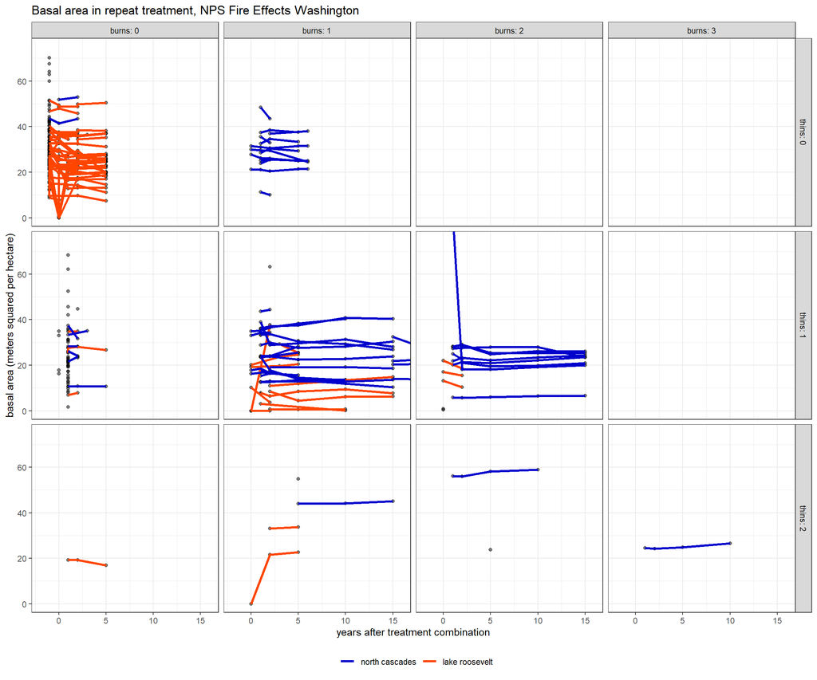

```r
basal_area <- gg_facet(basal_area) +
  ## Note my x scale cut off ten data points at the 20 years mark,
  ## mostly one thin one burn,
  ## to get better spread on most the data.
  coord_cartesian(xlim = c(-2,16), ylim = c(0,75)) +
  ggtitle('Basal area in repeat treatment, NPS Fire Effects Washington') +
  ylab('basal area (meters squared per hectare)')
basal_area
```

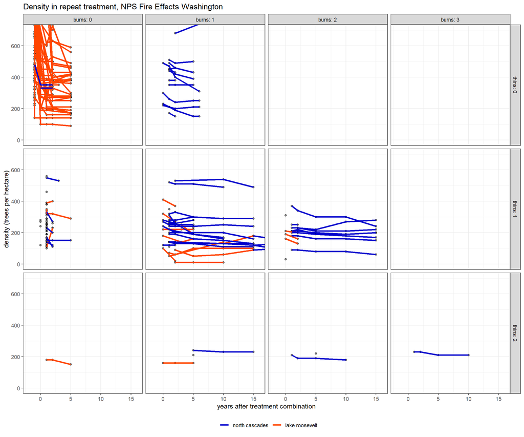

```r
density <- gg_facet(density) +
  coord_cartesian(xlim = c(-2, 16), ylim = c(0, 700)) +
  ggtitle('Density in repeat treatment, NPS Fire Effects Washington') +
  ylab('density (trees per hectare)')
density
```

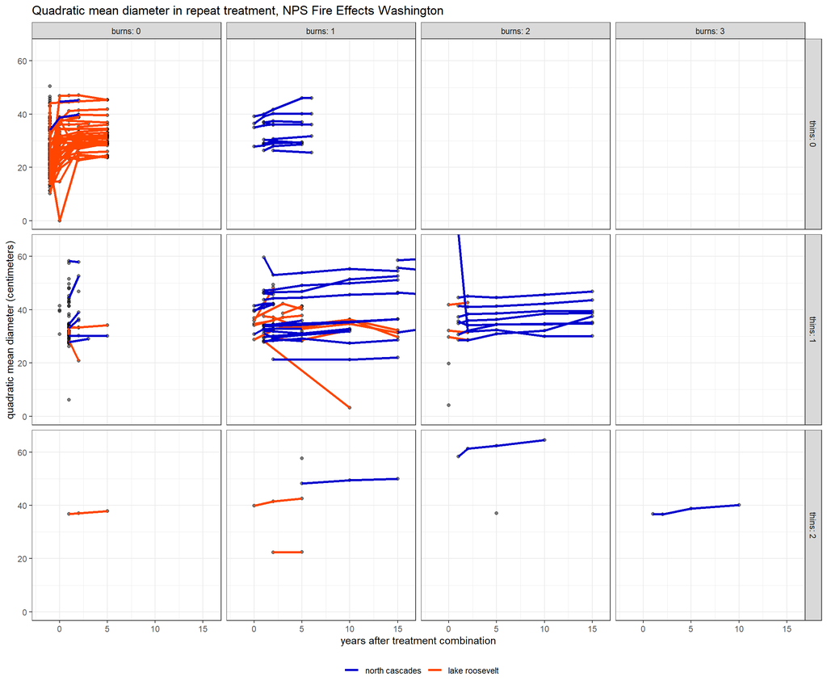

```r
qmd <- gg_facet(qmd) +
  coord_cartesian(xlim = c(-2, 16), ylim = c(0,65)) +
  ggtitle('Quadratic mean diameter in repeat treatment, NPS Fire Effects Washington') +
  ylab('quadratic mean diameter (centimeters)')
qmd
```

## Longitudinal Graphs

Below I delete some areas with very few observations, to simplify the longitudinal graphs which are gridded by area

```r
trees_for_long <- trees %>%
  filter(area != 'copa' & area != 'gifford ferry' & area != 'log yard c' &
           area != 'ricky north' & area != 'ponderosa' & area != 'riverway b' &
           area != 'lower mcgregor' & area != 'mcgregor')
```

```r
gg_longitudinal <- function(var){
  yvar = enquo(var)
  ggplot(trees_for_long, aes(x = year, y = !!yvar, group = plot, color = treatment)) +
  facet_wrap(area ~ region) +
  geom_line(size = 1.1, aes(color = treatment)) +
  scale_color_manual(values = treatment_colors) +
  simpletheme +
  theme(axis.title.x = element_blank())
}
```

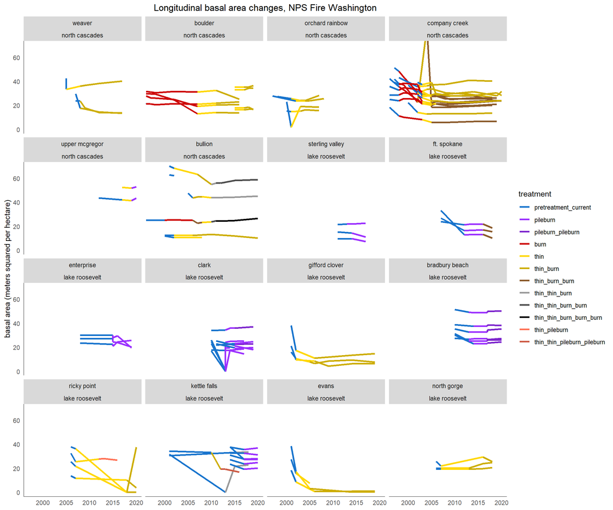

```r
basal_area_one <- gg_longitudinal(basal_area) +
  ggtitle('Longitudinal basal area changes, NPS Fire Washington') +
  ylab('basal area (meters squared per hectare)') +
  coord_cartesian(xlim = c(1997, 2020), ylim = c(0, 70))
basal_area_one
```

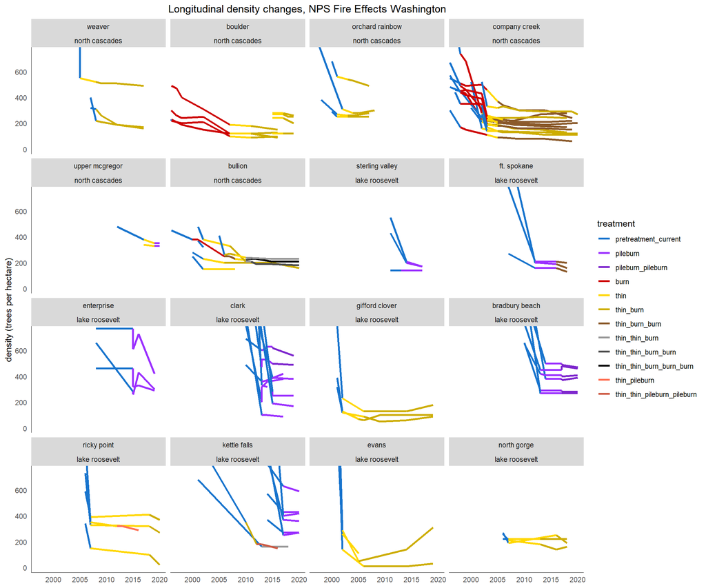

```r
density_one <- gg_longitudinal(density) +
  ggtitle('Longitudinal density changes, NPS Fire Effects Washington') +
  ylab('density (trees per hectare)') +
  coord_cartesian(xlim = c(1997, 2020), ylim = c(0, 750))
density_one
```

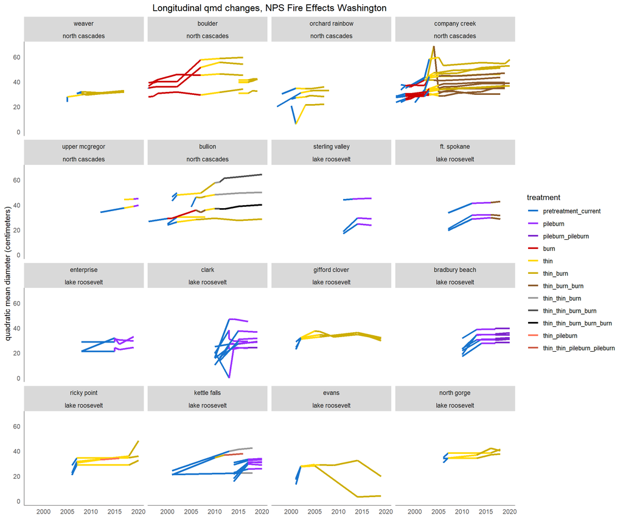

```r
qmd_one <- gg_longitudinal(qmd) +
  ggtitle('Longitudinal qmd changes, NPS Fire Effects Washington') +
  ylab('quadratic mean diameter (centimeters)') +
  coord_cartesian(xlim = c(1997, 2020))
qmd_one
```

# Initial thoughts

It’s really cool to get to check out this kind of longtitudinal data. It looks like what we can really compare is burn, thinburn, and thinburnburn, without much longevity for burn but with 15+ year longevity for the other two treatments. Adding the Lake Roosevelt data may help fill out this matrix a bit, and we could also talk about eventually bringing in data from sites from other states.

One idea I’ve had floating around was to compare five year responses of the different treatments, which will let us bring in the burn data. For the thin burn and thin burn burn, we could include them in our fuels longevity report, although there may be some psuedoreplication issues since the long-running plots seem to have come from the same areas (moreso with thinburnburn).

It certainly looks like pretreatment value is critically important. It also looks like there are possibly some diminishing returns to repeated treatment. Maybe this is by design in the case of multiple thinning (i.e. subsequent thins are less intense than the initial), in which case we’ll have to think about using thin as a continous variable or using a cost benefit analysis. Patterns could of course be different with the other response variables.

We’ll likely need to think about accounting for spatial autocorrelation and/or using a random effects framework with the different stands. I’ve also been wondering about the effect of different treatment histories like order of treatments or time between treatments for something like thinburn or thinburnburn, but it looks like in many cases comparable plots have similar temporal histories, likely they’re from the same group of stands. The order of thinning and burning is variable though, which will be important to keep in mind.

Some questions for Karen:

1. Can you please pass along the link for the Lake Roosevelt dataset?
2. Do you know why there are NA’s in many of the dbh columns? This mostly affected the immediate year zero posttreatment data, but not exclusively.
3. Do you know if there are canopy base height data? I didn’t see them on the tree data file.
4. What’s your sense of how much the ‘Macroplot Purpose’ study areas, which I’ve just renamed to area, act as distinct stands vs. more administrative boundaries? Some of these are contiguous so just wondering how much stock to put in the distinctions.
5. What’s your sense of how much different second and third thins/burns were purposefully implemented differently than initial treatments?
6. What was the selection process for retreatment?

This is just my first pass at the data, and I’ll give it lots more thought! Looking forward to hearing your insights, especially from Karen.